# Exploratory Data analysis

Nishanth Gandhidoss

2 October 2016

## Exploratory Data Analysis Assignment

**Due: Oct. 7, 2016**

For this assignment you will be exploring two sets of data. For the first focus on NFL sports data, you will be completing the assignment alone (each student by themselves). For the second part, focusing on the Spotify data, you may work in the groups (the same groups as the Case Study).

**NFL Data**

The use of data analysis in sports is becoming increasing more common (and a high profit business). Interest in this analysis grew substantially with the publishing of the book Moneyball (and the subsequent movie). Statistical analysis has spread to many other sports including basketball, football (both American and soccer), tennis, and many others.

- nfl-passing-2012.csv,
- nfl-passing-2013.csv,
- nfl-passing-2014.csv, and
- nfl-passing-2015.csv

The four data sets consist of passing statistics of NFL quarterbacks for the last four seasons. The data was sourced from: http://www.pro-football-reference.com/years/2015/passing.htm

**Importing the data**

The datasets are imported using read.csv() method to compute the required values.

**Q1. 2015 Data**

First, examine a single data source from the 2015 season.

Report the following information as values, tables, and/or figures.

1. Calculate the mean, median, and mode of touchdowns and interceptions.

```
## [1] "Mean is 9.7906976744186"
## [1] "Median is 4"
## [1] "Mode is 0"
```

```
## [1] "Mean is 5.06976744186047"
## [1] "Median is 4"
## [1] "Mode is 0"
```

2. Calculate the first and third quartiles, Q1 and Q3 of Yds and Rate

```
## [1] "First Quartile is 38"
## [1] "Third Quartile is 3182"
```

```
## [1] "First Quartile is 71.975"
## [1] "Third Quartile is 95.175"
```

3. Present the five-number summary of Cmp% and Yds as a table

```
##    Min. 1st Qu.  Median    Mean 3rd Qu.    Max.
##    1.00    6.25  111.50  212.80  406.20  661.00
```

```
##    Min. 1st Qu.  Median    Mean 3rd Qu.    Max.
##      -3      38     759    1543    3182    4870
```

4. Create a histogram of yards with 8, 16, and 24 bins.

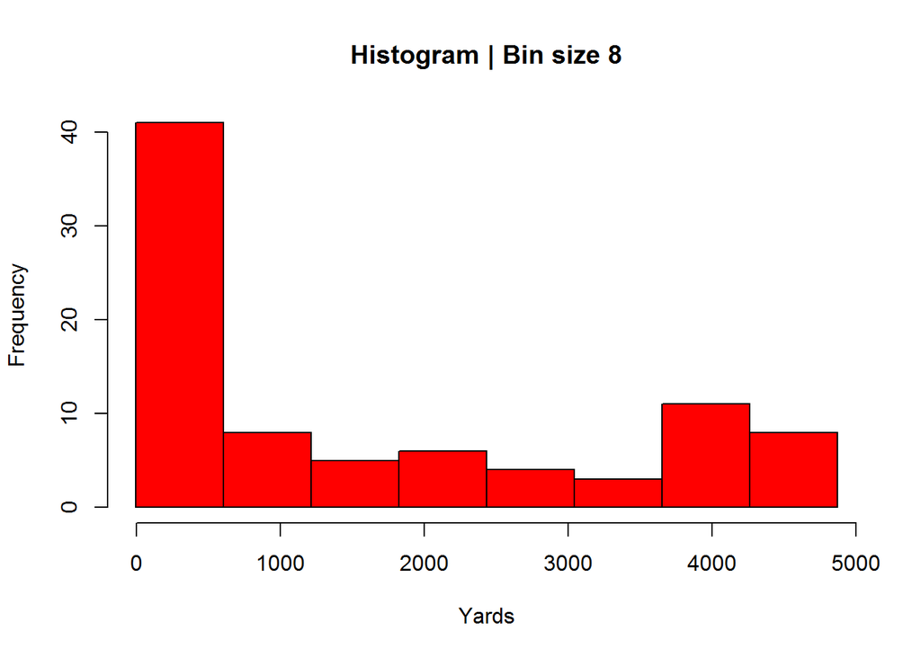

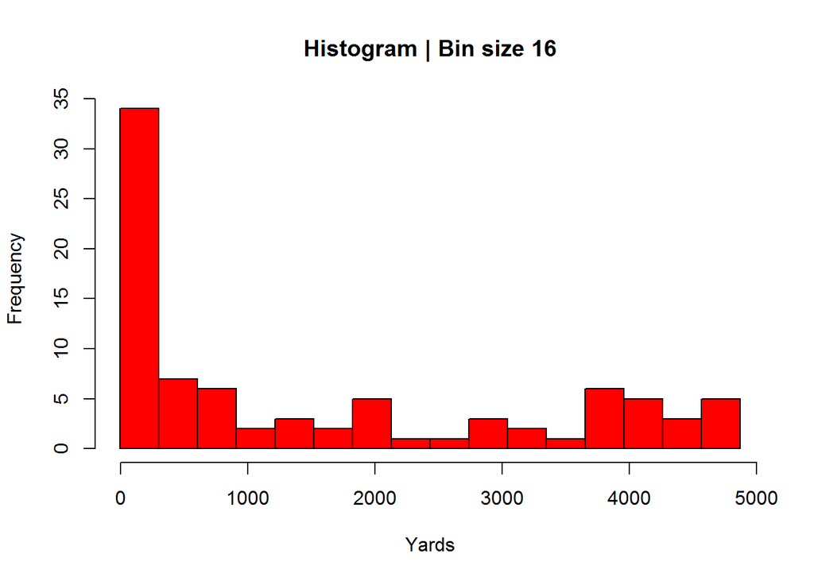

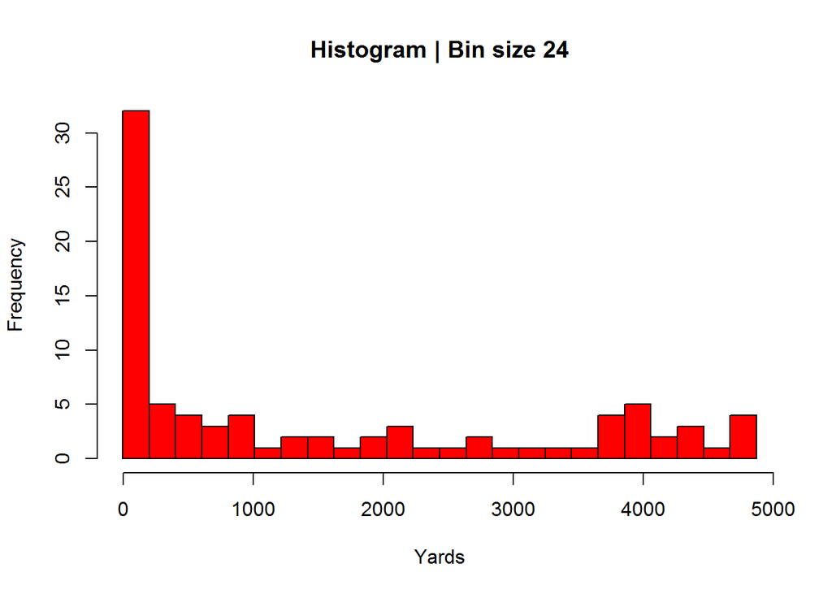

5. Compare the distrubtion of yards based on whether they threw less than 12 interceptions.

[figure not shown]

6. Create a scatterplot of touchdowns vs. interceptions.

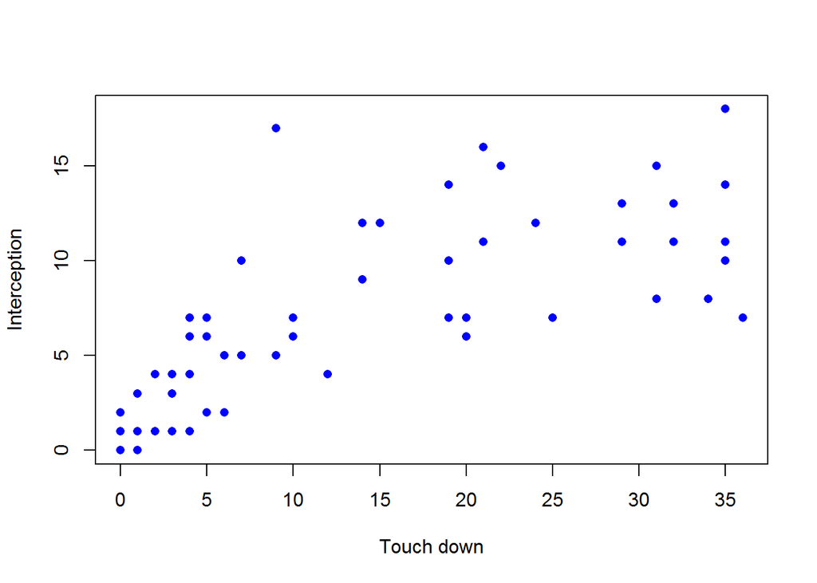

**Q2. 2014 Data**

Repeat the analysis above with the data from the 2014 season.

1. Calculate the mean, median, and mode of touchdowns and interceptions.

```
## [1] "Mean is 8.07"
## [1] "Median is 2"
## [1] "Mode is 0"
```

```
## [1] "Mean is 4.5"
## [1] "Median is 2"
## [1] "Mode is 0"
```

2. Calculate the first and third quartiles, Q1 and Q3 of Yds and Rate

```
## [1] "First Quartile is 19.75"
## [1] "Third Quartile is 2493.5"
```

```
## [1] "First Quartile is 56.4"
## [1] "Third Quartile is 96.425"
```

3. Present the five-number summary of Cmp% and Yds as a table

```
##    Min. 1st Qu.  Median    Mean 3rd Qu.    Max.
##    1.00    1.75   44.00  178.80  337.00  659.00
```

```
##    Min. 1st Qu.  Median    Mean 3rd Qu.    Max.
##    0.00   19.75  262.00 1289.00 2494.00 4952.00
```

4. Create a histogram of yards with 8, 16, and 24 bins.

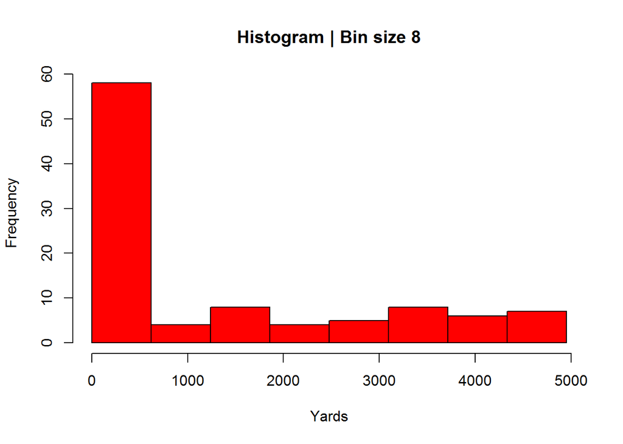

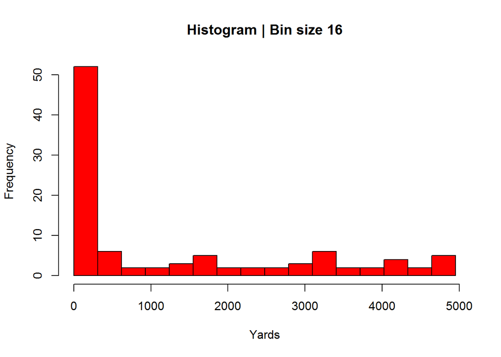

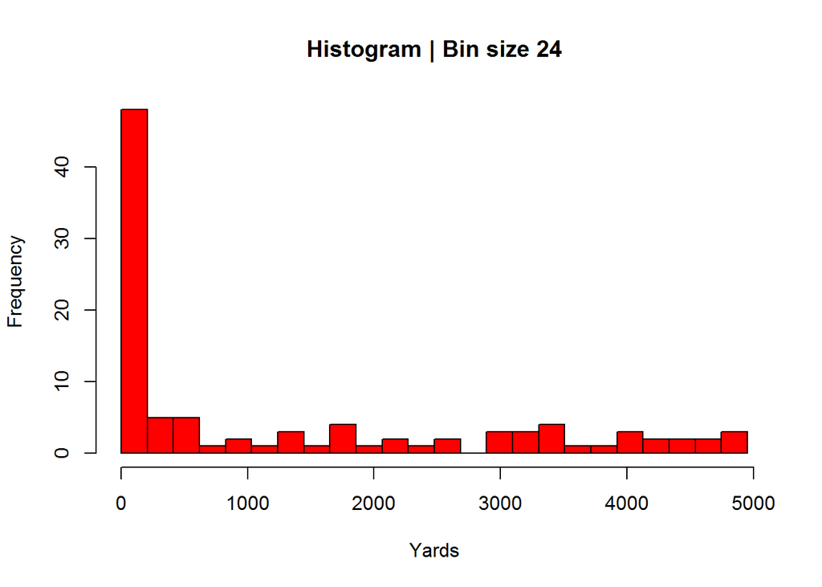

5. Compare the distrubtion of yards based on whether they threw less than 12 interceptions.

[figure not shown]

6. Create a scatterplot of touchdowns vs. interceptions.

[figure not shown]

**Q3. All Seasons**

For this part of the assignment, you should look at variables across all four seasons. The merge should match players across seasons (using a key of player names). Ensure that the variables that may be named the same in the four data files all appear in the final data for analysis.

Select a set of players that has played in at least 5 games in each season and has made at least 100 attempts in each season.

Report the following information as values, tables, and/or figures.

1. Calculate the mean, median, and mode of average touchdowns across the four seasons.

```
## [1] "Mean is 25.7763157894737"
## [1] "Median is 25.25"
## [1] "Mode is 36.75"
```

2. Create a scatterplot of average touchdowns vs. average completion percentage.

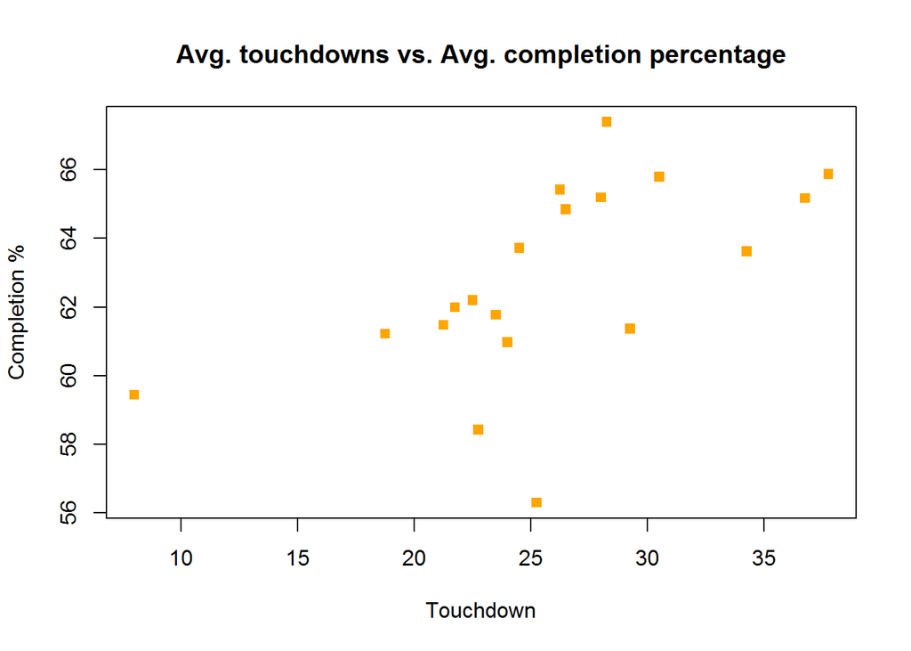

3. Repeat the scatterplot of touchdowns vs. completion percentage using color to indicate which season.

[figure not shown]

4. Draw a histogram of yards using color to indicate which season.

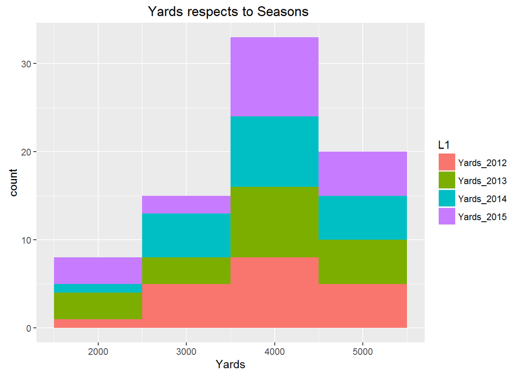

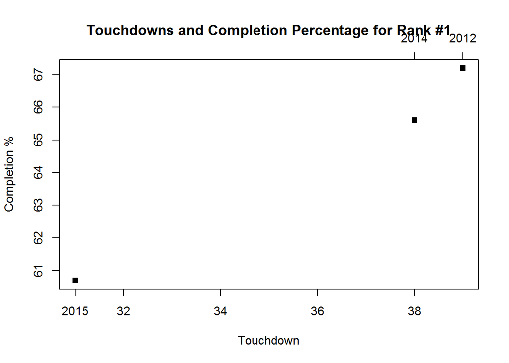

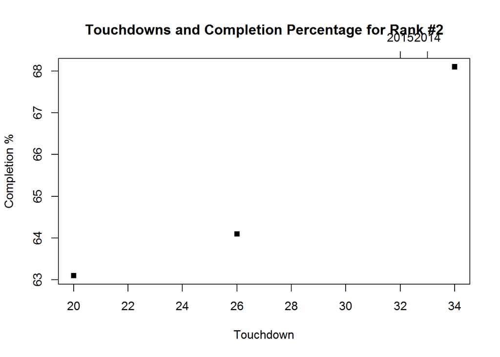

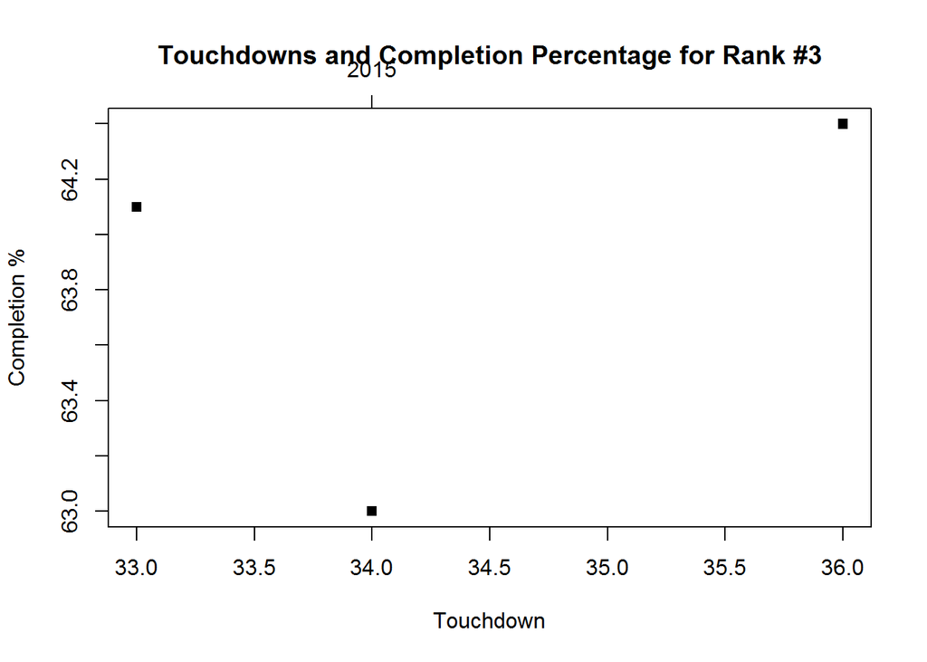

6. Show four tables with the top 5 QBs each season selected by ESPN’s quarterback rating and the following variables: yards, touchdowns, interceptions, completion percentage.

```
##    quaterbacks yards touchdown interceptions completion
## 14       84.11  4659        37            11        400
## 19       77.05  4827        34             8        401
## 11       74.50  4719        32            14        422
## 1        72.48  4295        39             8        371
## 16       69.59  3118        26            10        252
```

```
##    quaterbacks yards touchdown interceptions completion
## 1        82.64  4381        38             5        341
## 14       77.25  4727        39            15        395
## 19       74.32  4109        33             9        373
## 4        72.48  4952        32             9        408
## 7        71.56  4952        33            17        456
```

[output not shown]

```
##    quaterbacks yards touchdown interceptions completion
## 6        82.15  4671        35            11        342
## 4        76.86  3938        21            16        319
## 7        75.47  4870        32            11        428
## 16       74.91  4024        34             8        329
## 3        73.11  3250        25             7        255
```

## Spotify Data

For this question, you will want to use the data from Case Study 1.

**Getting the song list**

To start you will show your understanding and exploration of the data and its features.

For every song on the you will have the following features:

- song title (track)
- artist
- peak (highest spot on the charts)
- date entered (when the song first appeared on the charts)
- successful (criteria to be predicted)

In addition, you will collect the audio features from Spotify:

- danceability
- energy
- key
- loudness
- mode
- speechiness
- acousticness
- instrumentalness
- liveness
- valence
- tempo
- duration_ms
- time_signature

**Getting the audio feautures data from spotify and merge it with the given song list**

**Q4. Features**

For each audio feature, make sure you understand what the features are, what are the possible values, etc. Read the Spotify API describing the audio features.

[output not shown]

[output cut: 71 more lines]

[output not shown]

```
##                       id                    Title          Artist Peak
## 1 00Mb3DuaIH1kjrwOku9CGU                Sk8er Boi   Avril Lavigne   10
## 2 01Aj44KIjCrPmZeXq4UOky                  Emotion Destiny's Child   10
## 3 01CnYyPXMFRzOFVQBU8WMb This One's For The Girls Martina McBride   39
## 4 01ITmYotdoow6gqRXv7oMo           Ain't It Funny  Jennifer Lopez    1
## 5 02UnamzTn2rySwzcMkq5qx                   I Melt   Rascal Flatts   34
## 6 03B0yrE4zrioHjmY05l9xz       Make Her Feel Good    Teairra Mari   35
##   Date.Entered Successful danceability energy key loudness mode
## 1      9/14/02          1        0.487    0.9   0   -4.417    1
## 2      9/29/01          1        0.412  0.577   7   -4.944    1
## 3       8/9/03          0        0.613  0.801   8   -4.431    1
## 4     12/29/01          1        0.707   0.87   0   -4.533    0
## 5      8/23/03          0        0.556  0.712   9   -4.398    1
## 6       6/4/05          0         0.82   0.67   2   -9.422    1
##   speechiness acousticness instrumentalness liveness valence   tempo
```

[output cut: 34 more lines]

**Missing Data**

Are any of the songs not available in Spotify? If so this is an easy example of what to do with missing data, because the entire row will be deleted from the data set.

```
## 'data.frame':    6 obs. of  23 variables:
##  $ id              : chr  "00Mb3DuaIH1kjrwOku9CGU" "01Aj44KIjCrPmZeXq4UOky" "01CnYyPXMFRzOFVQBU8WMb" "01ITmYotdoow6gqRXv7oMo" ...
##  $ Title           : chr  "Sk8er Boi" "Emotion" "This One's For The Girls" "Ain't It Funny" ...
##  $ Artist          : chr  "Avril Lavigne" "Destiny's Child" "Martina McBride" "Jennifer Lopez" ...
##  $ Peak            : chr  "10" "10" "39" "1" ...
##  $ Date.Entered    : chr  "9/14/02" "9/29/01" "8/9/03" "12/29/01" ...
##  $ Successful      : chr  "1" "1" "0" "1" ...
##  $ danceability    : chr  "0.487" "0.412" "0.613" "0.707" ...
##  $ energy          : chr  "0.9" "0.577" "0.801" "0.87" ...
##  $ key             : chr  "0" "7" "8" "0" ...
##  $ loudness        : chr  "-4.417" "-4.944" "-4.431" "-4.533" ...
##  $ mode            : chr  "1" "1" "1" "0" ...
##  $ speechiness     : chr  "0.0482" "0.119" "0.0354" "0.0465" ...
##  $ acousticness    : chr  "1e-04" "0.163" "0.0626" "0.0691" ...
##  $ instrumentalness: chr  "0" "0" "0" "3e-04" ...
##  $ liveness        : chr  "0.358" "0.0969" "0.124" "0.138" ...
##  $ valence         : chr  "0.484" "0.35" "0.599" "0.619" ...
##  $ tempo           : chr  "149.937" "173.675" "126.966" "99.833" ...
##  $ type            : chr  "audio_features" "audio_features" "audio_features" "audio_features" ...
##  $ uri             : chr  "spotify:track:00Mb3DuaIH1kjrwOku9CGU" "spotify:track:01Aj44KIjCrPmZeXq4UOky" "spotify:track:01CnYyPXMFRzOFVQBU8WMb" "spotify:track:01ITmYotdoow6gqRXv7oMo" ...
##  $ track_href      : chr  "https://api.spotify.com/v1/tracks/00Mb3DuaIH1kjrwOku9CGU" "https://api.spotify.com/v1/tracks/01Aj44KIjCrPmZeXq4UOky" "https://api.spotify.com/v1/tracks/01CnYyPXMFRzOFVQBU8WMb" "https://api.spotify.com/v1/tracks/01ITmYotdoow6gqRXv7oMo" ...
##  $ analysis_url    : chr  "https://api.spotify.com/v1/audio-analysis/00Mb3DuaIH1kjrwOku9CGU" "https://api.spotify.com/v1/audio-analysis/01Aj44KIjCrPmZeXq4UOky" "https://api.spotify.com/v1/audio-analysis/01CnYyPXMFRzOFVQBU8WMb" "https://api.spotify.com/v1/audio-analysis/01ITmYotdoow6gqRXv7oMo" ...
##  $ duration_ms     : chr  "204000" "236400" "243160" "244831" ...
##  $ time_signature  : chr  "4" "4" "4" "4" ...
```

Missing data are identified and removed from the dataset using ‘na.omit()’ and final dataset is transformed to a csv file ‘df.csv’. Attached with the assignment submission.

**Feature Types**

Describe which features are categorical? which are numeric?

**Numeric features**

```
    * Danceability
    * Energy
    * Acousticness
    * Valence
    * Tempo
    * Instrumentalness
    * Speechiness
    * Loudness
    * Liveness
    * Peak
    * Duration
```

**Categorical feautures**

```
    * Succesful
    * Mode
    * key
    * Time signature
```

**Numeric Data**

For each of the numeric features:

- Generate a histogram. Try at least two different values for the number of bins?

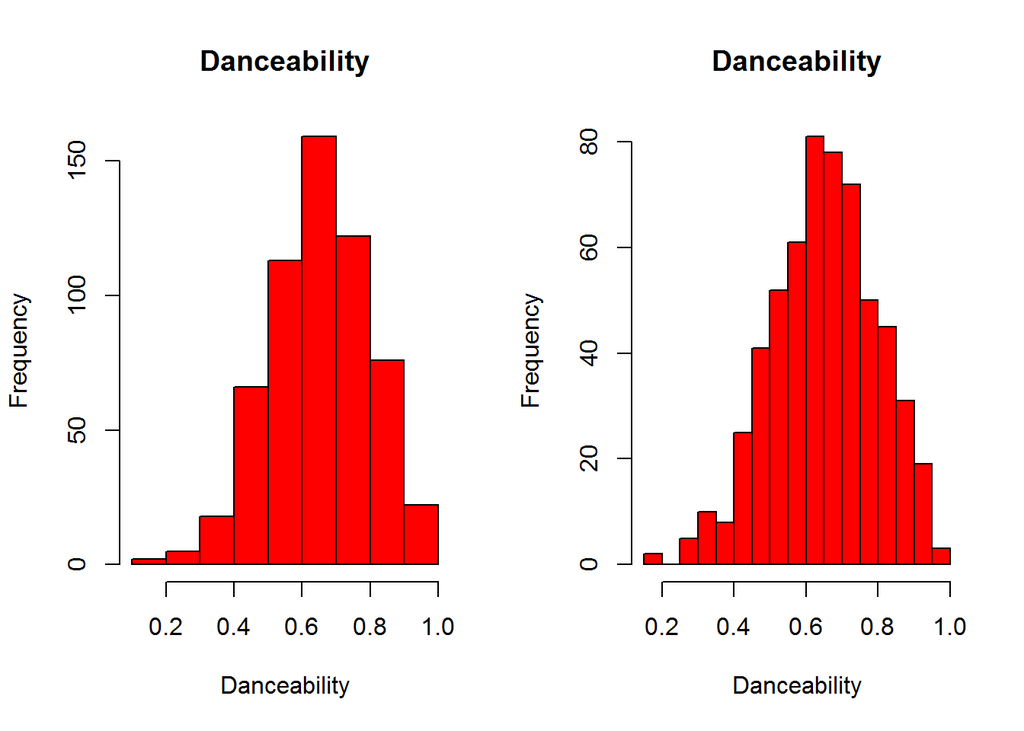

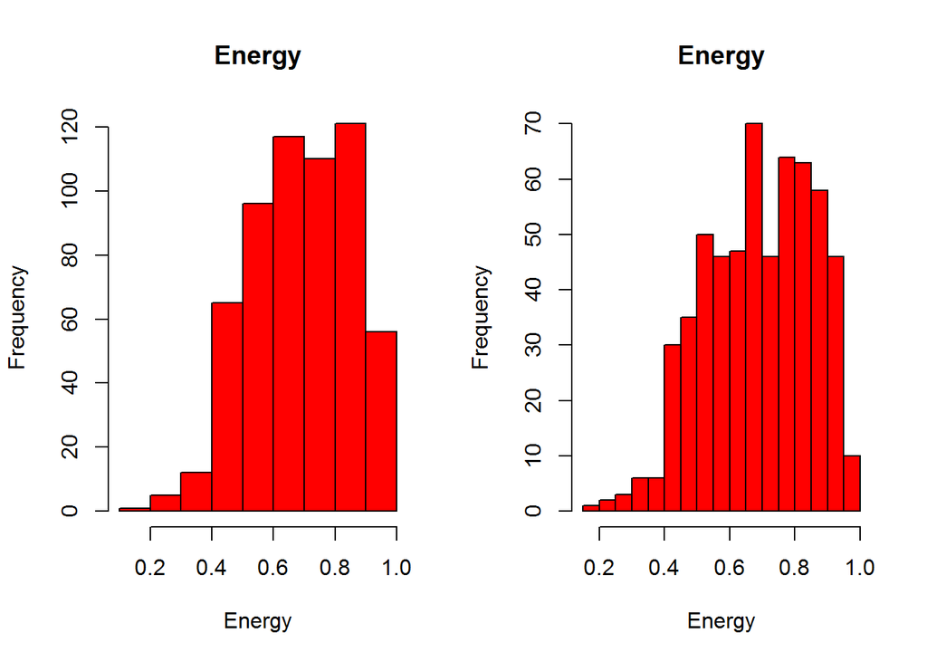

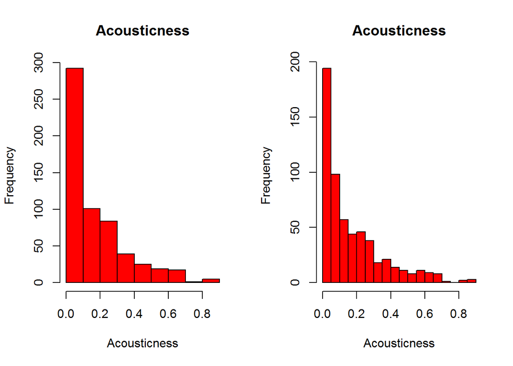

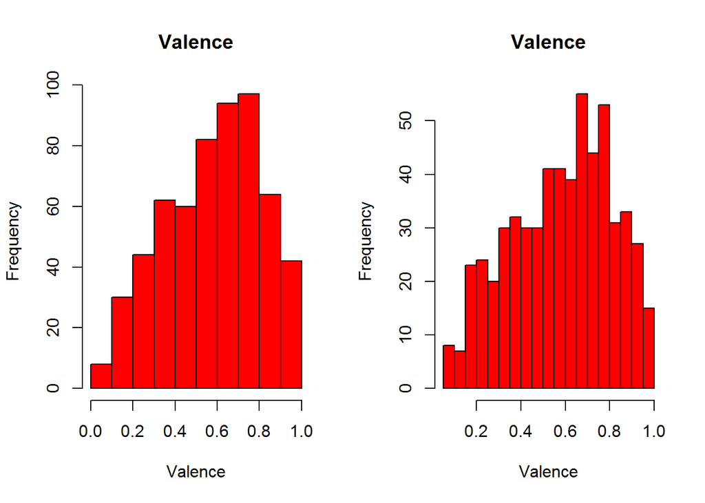

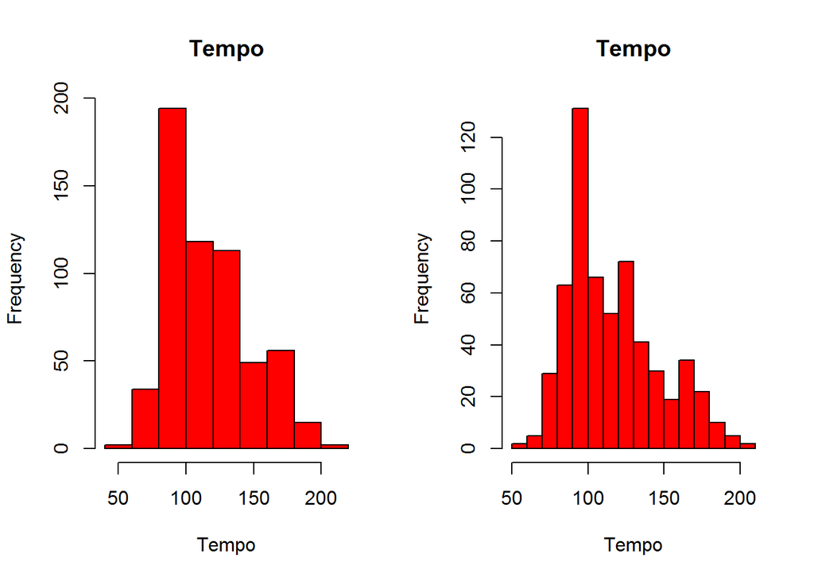

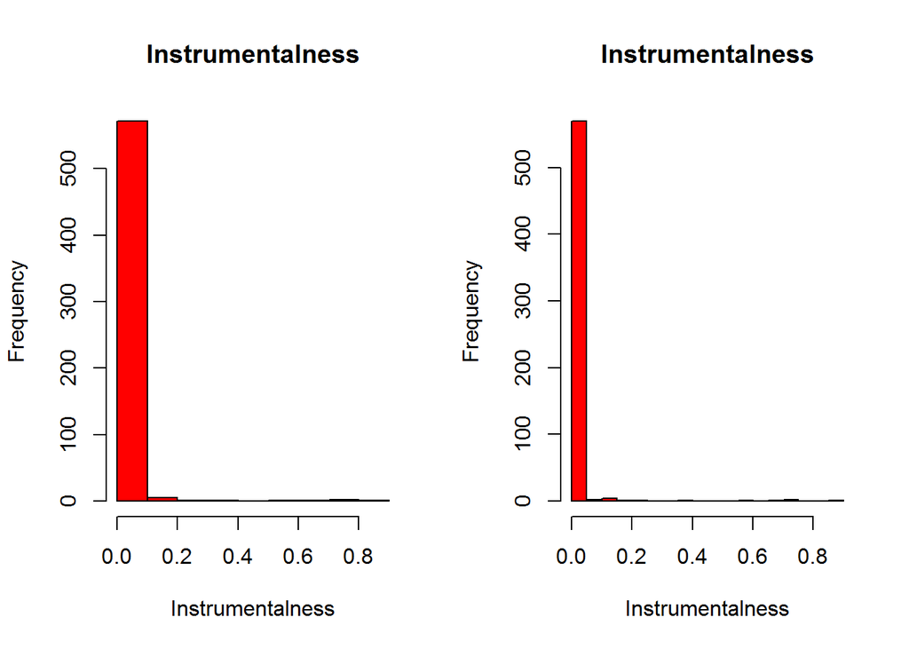

[figure not shown]

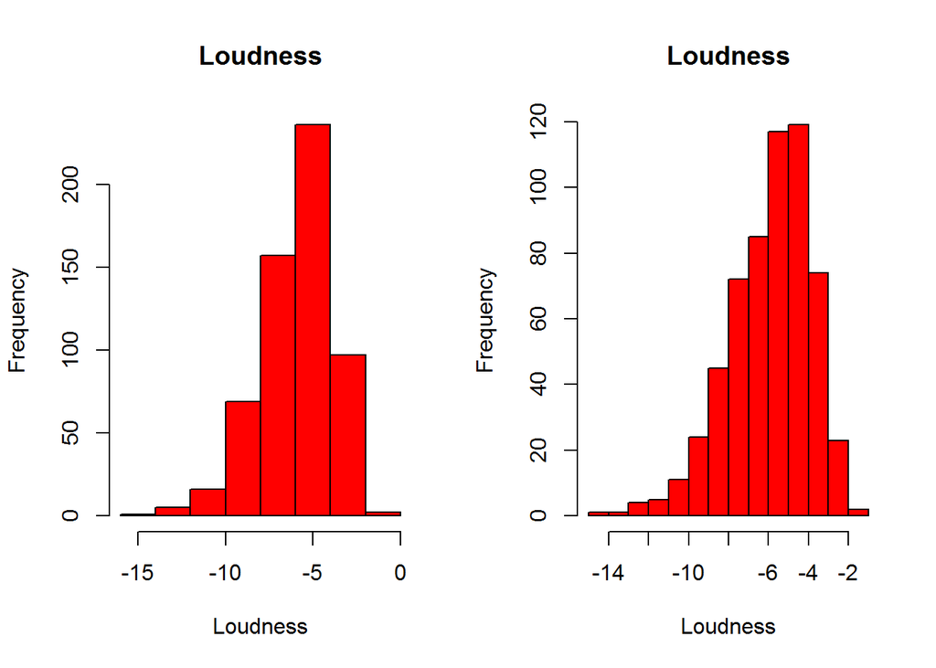

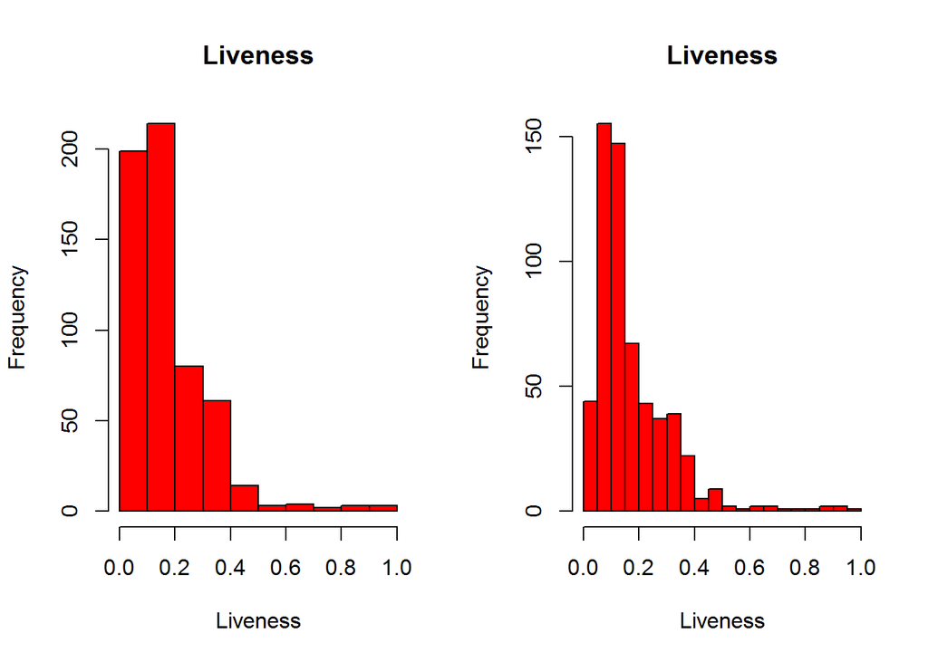

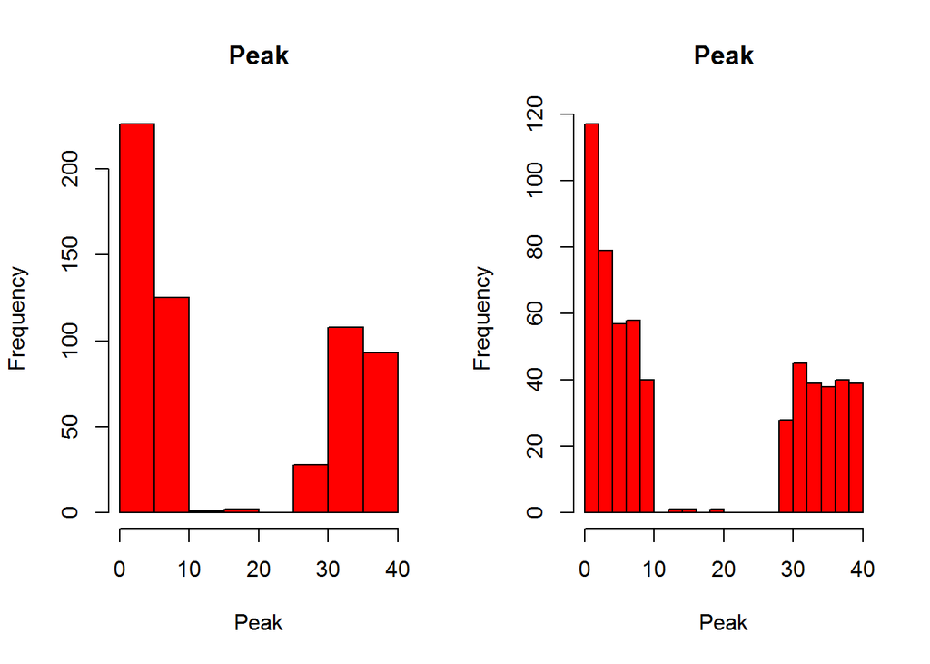

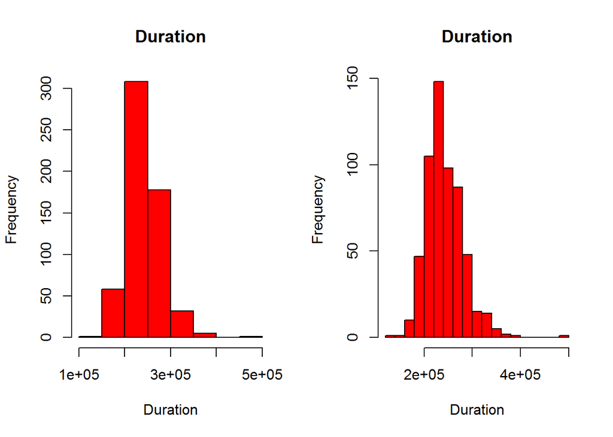

- Generate two histograms in the same figure (stacked side-by-side or one on top of another). In one histogram show the feature values for the successful songs, in the other histogram show the feature values for the unsuccessful songs.

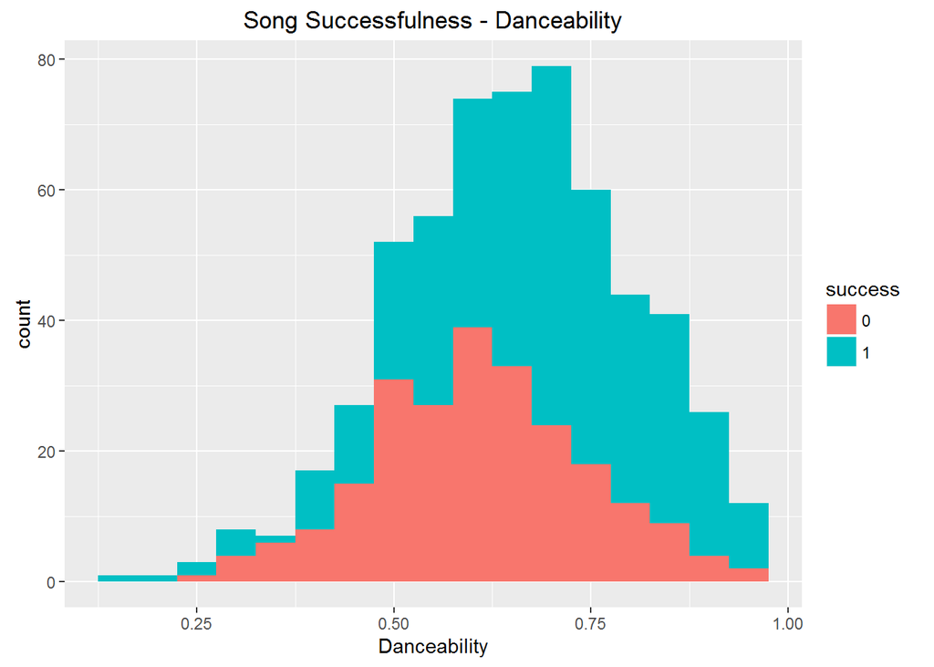

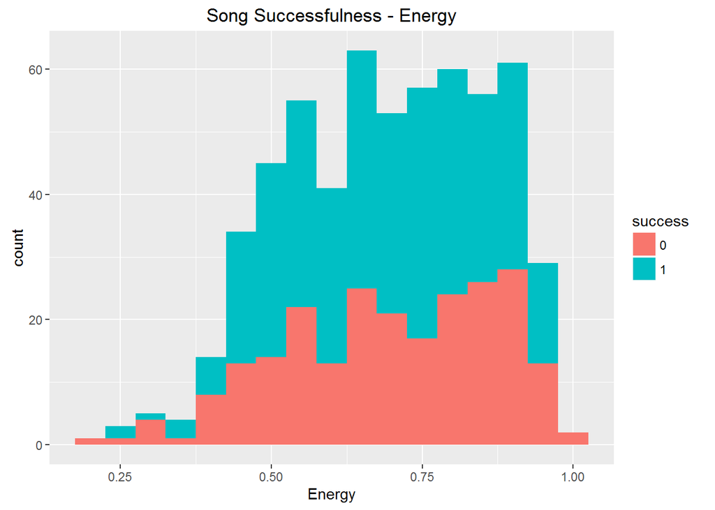

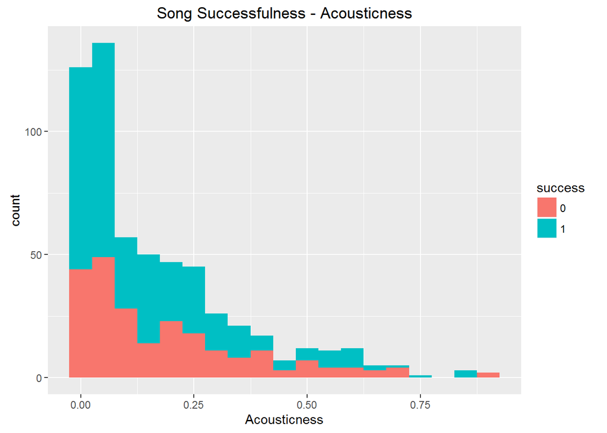

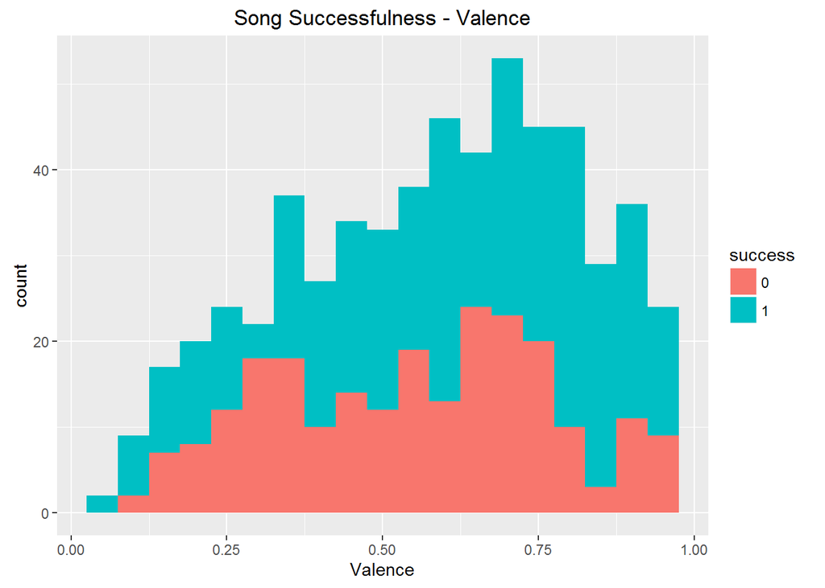

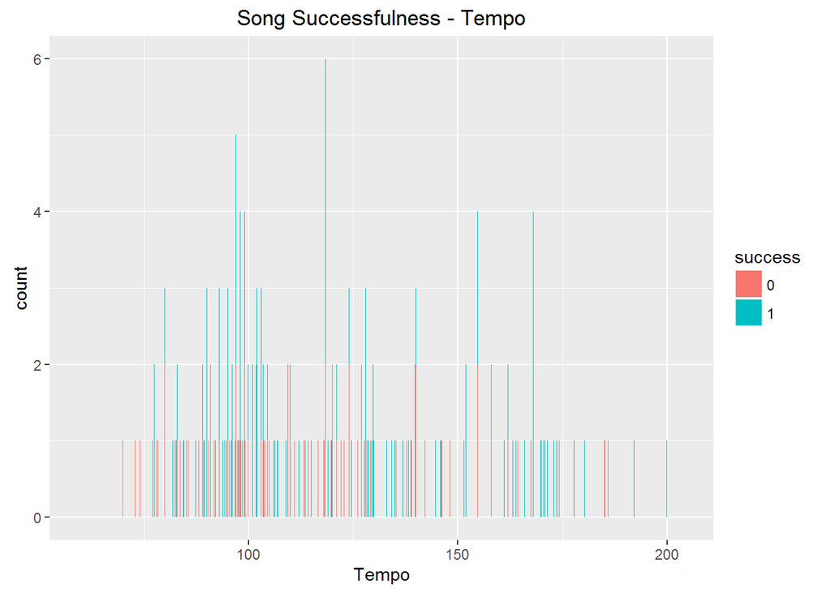

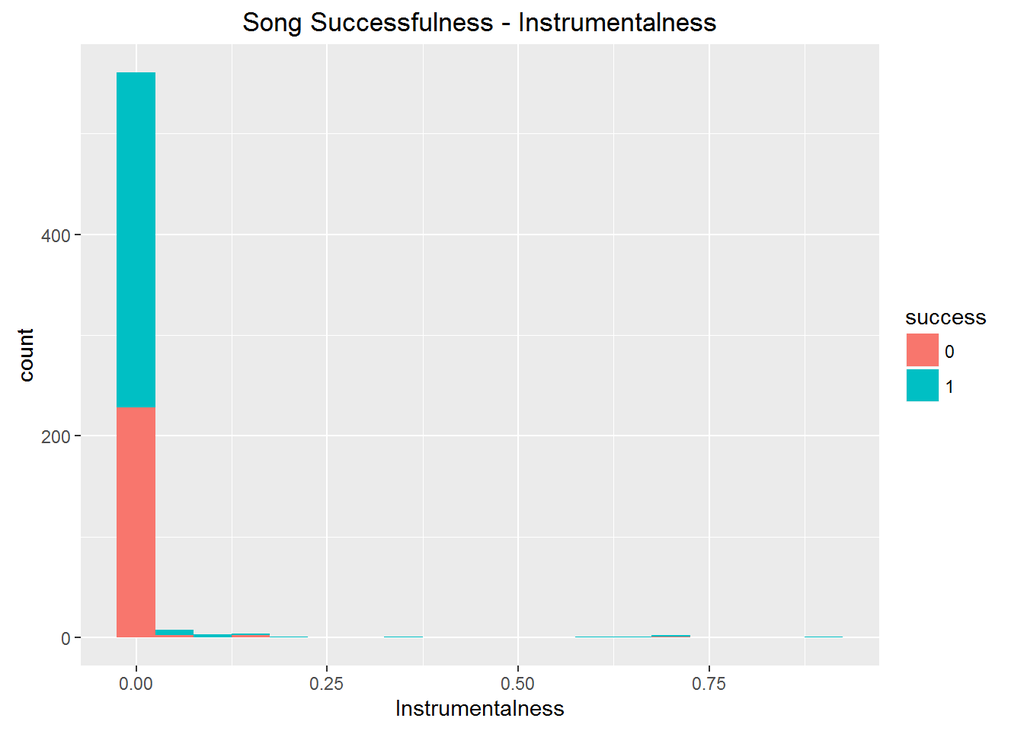

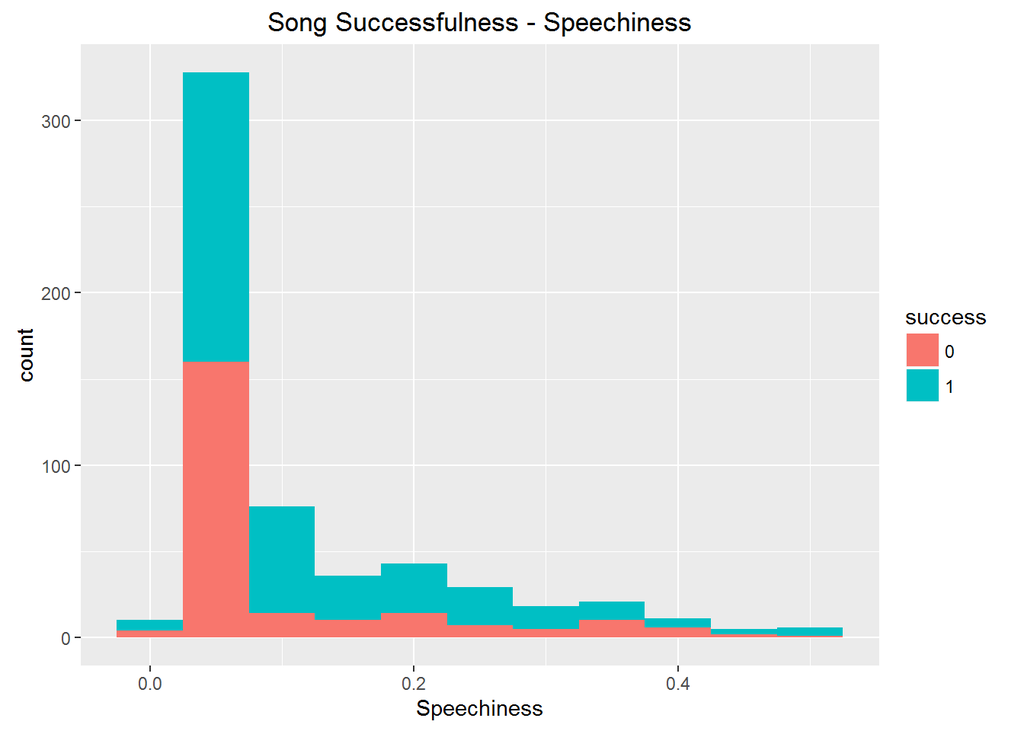

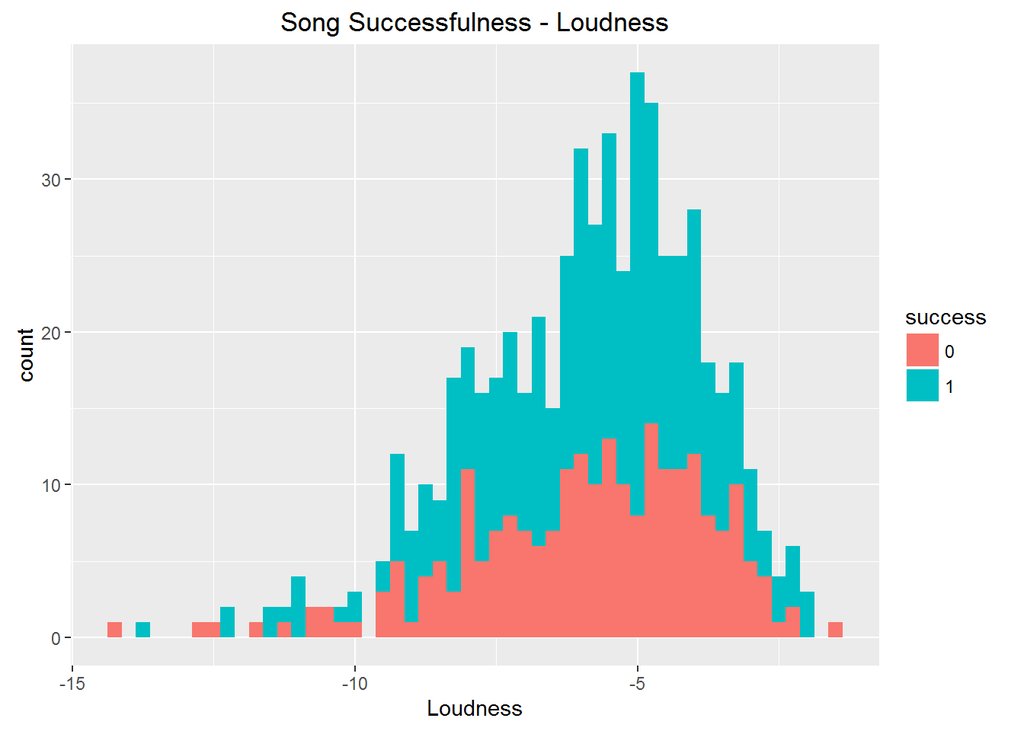

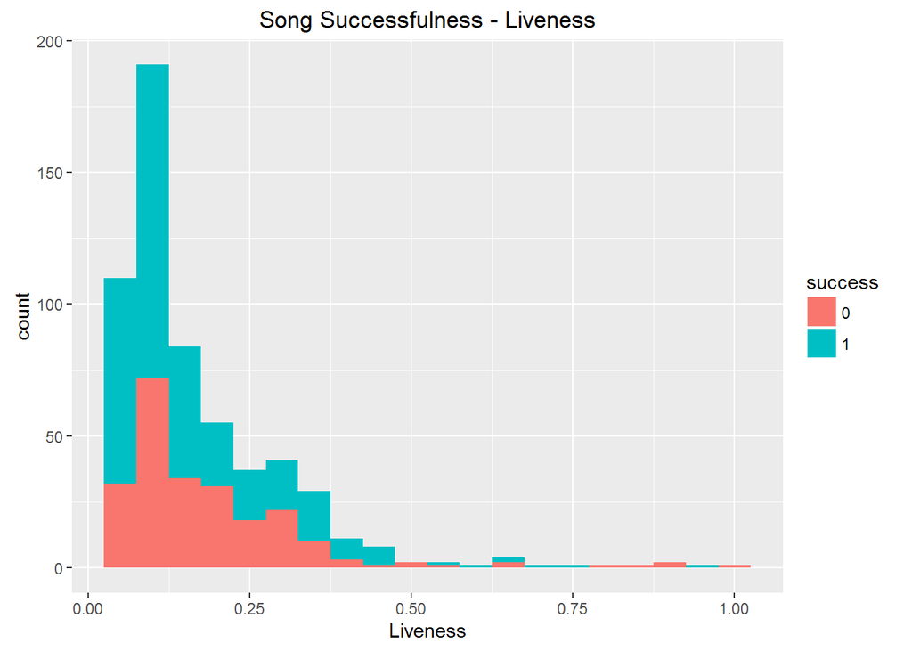

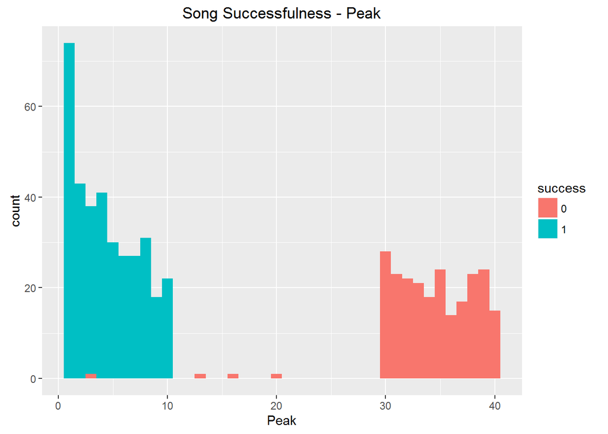

- Generate a figure with 2 boxplots side-by-side (or stacked on top of another), with the two boxplots corresponding to the songs from the two classes (successfulness).

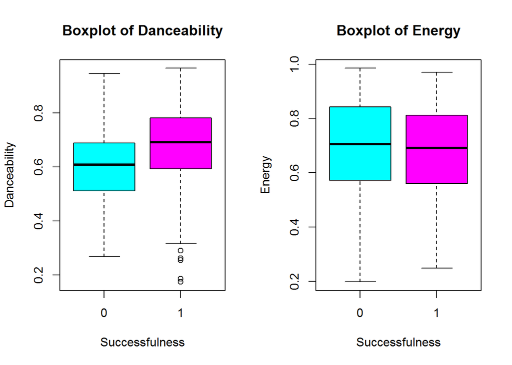

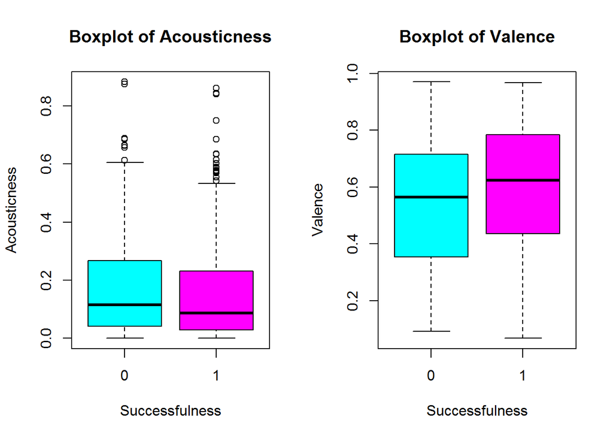

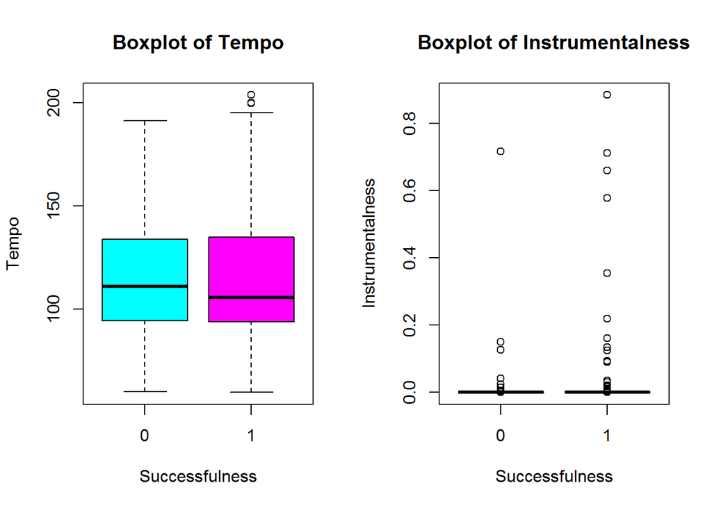

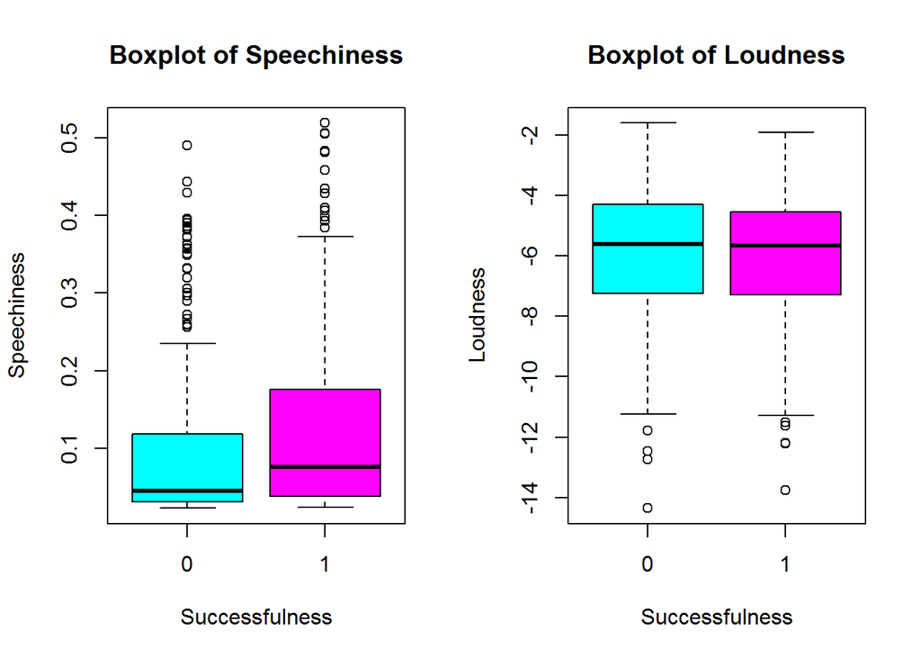

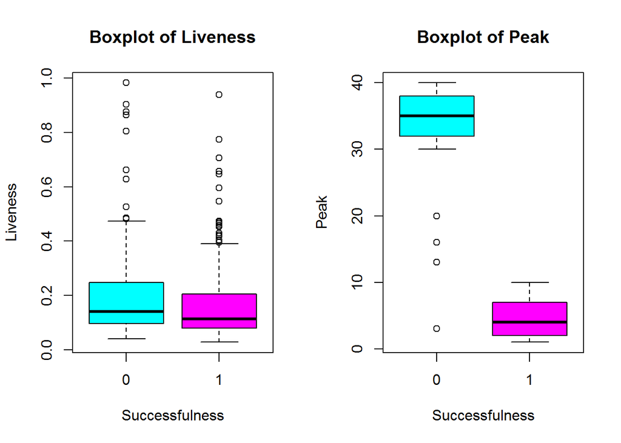

**Categorical Data**

For each of the categorical features:

- Generate a bar plot, showing the number of unique values.

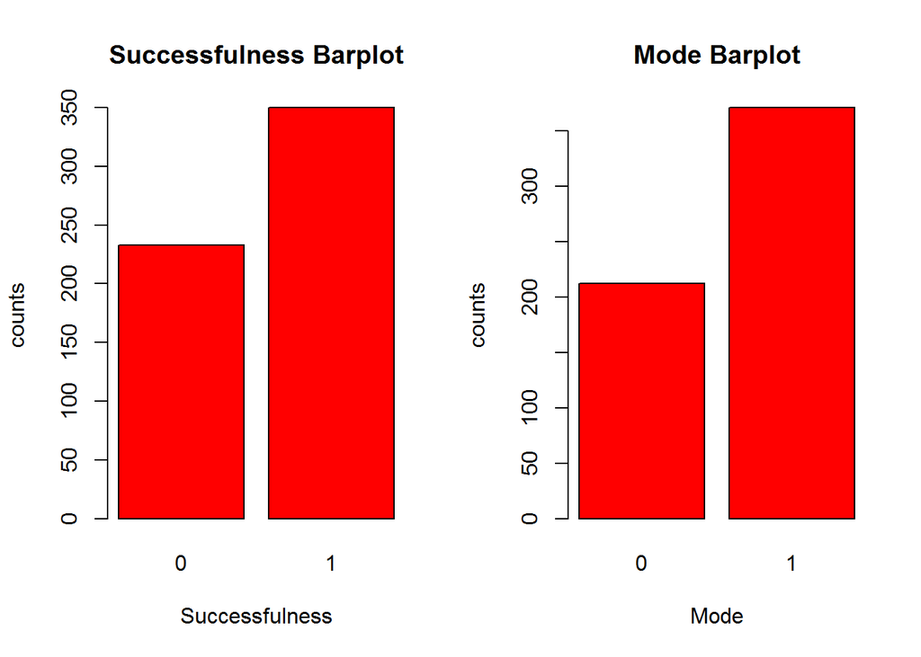

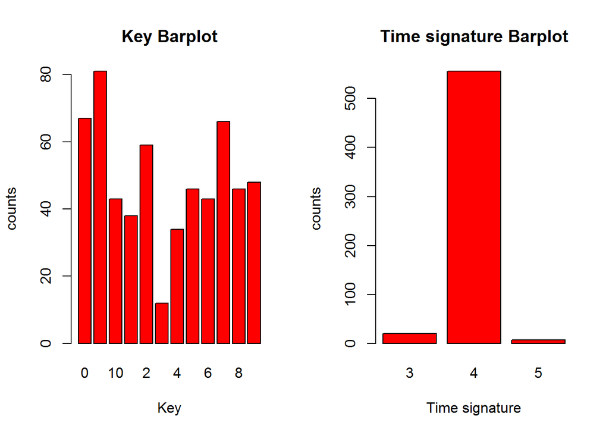

- Generate two bar plots in a single figure (stacked or side by side), with the two bar plots corresponding to the songs from the two classes. Then, summarize what if anything the plots have revealed about the data.

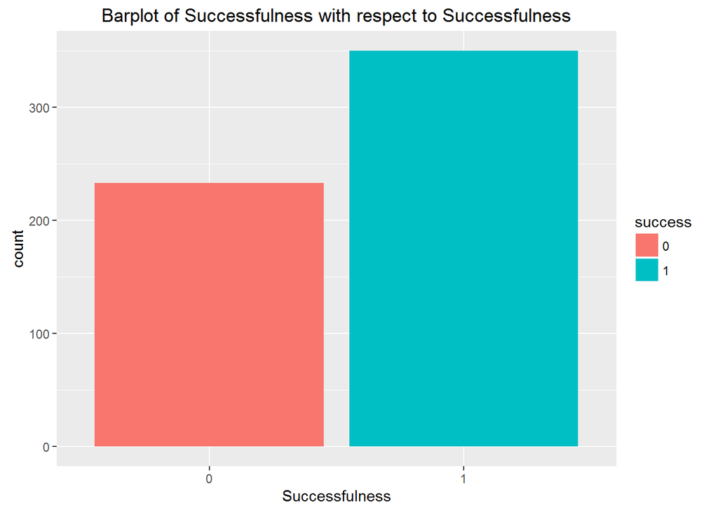

This graph shows the count of successful and unsucessful songs.

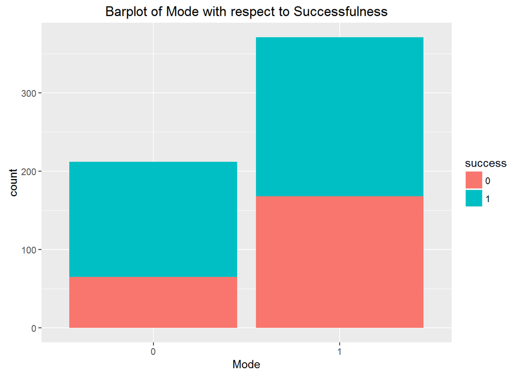

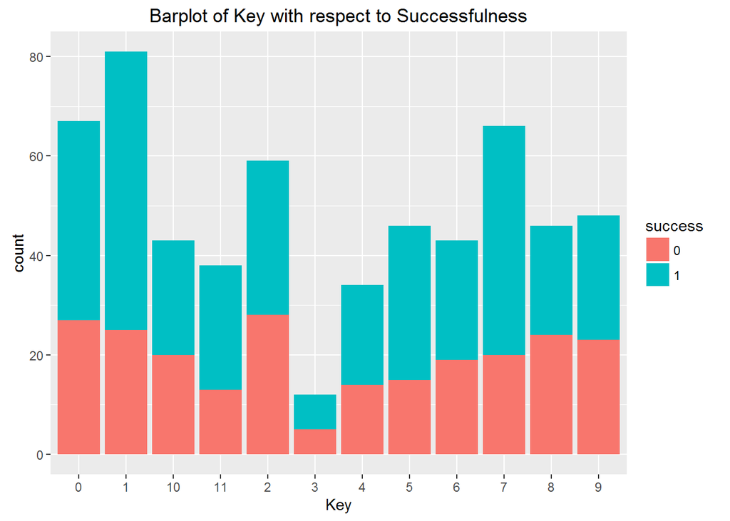

This does not reveal much about the data.

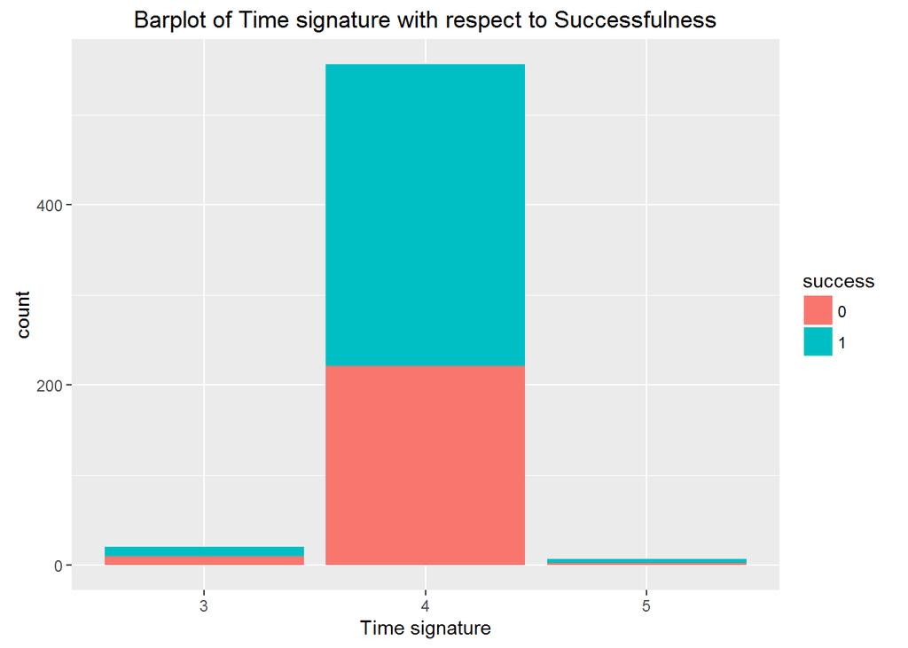

The time signature (meter) is a notational convention to specify how many beats are in each bar (or measure). And in this specified datasets most of the songs have 4 time signature. **Pairwise Analysis**

For the numeric variables, explore whether there are any pairwise relationships. Report the results with a figure and a description of what if any relationships are revealed.

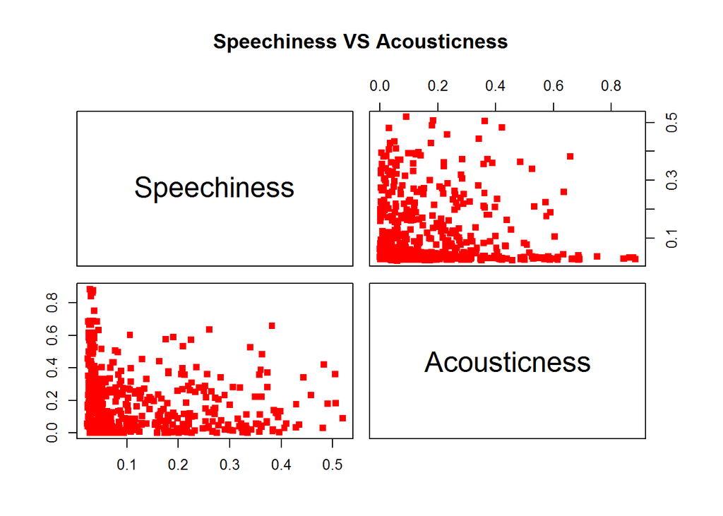

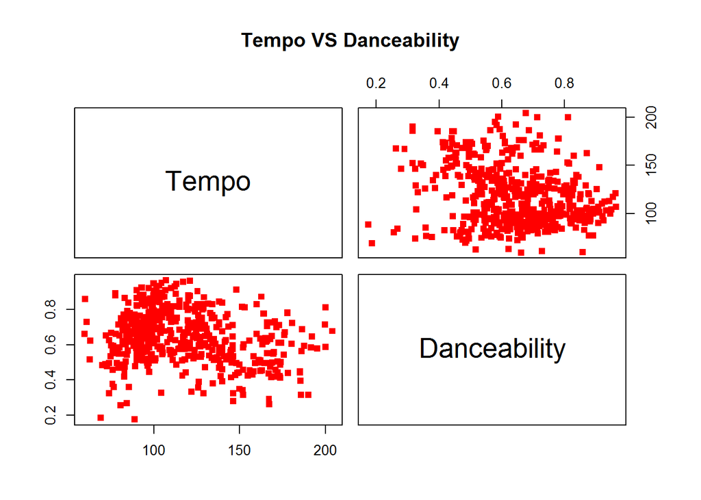

The pairwise analysis between Tempo and Danceability has weak correlation and both of them looks like inverse of one another.

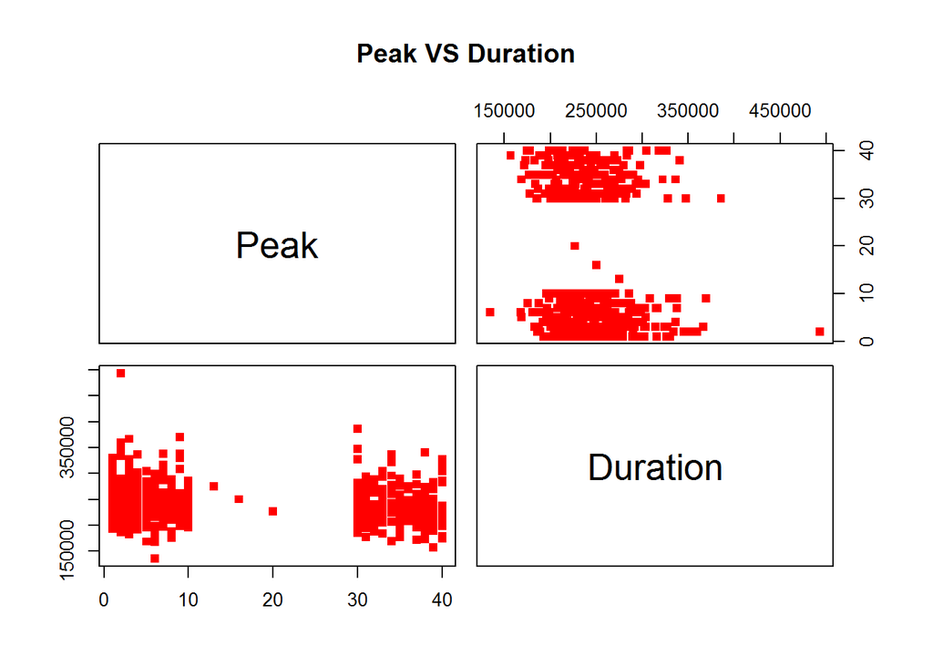